# Qualitative Prediction of Weightlifting Exercises

Krishanu Maitra

21 September 2018

## Executive Summary

In this project, we prepare a model to predict the manner in which certain weightlifting excercises are performed, i.e. correctly or incorrectly. This is based on data collected from accelerometers in wearable devices on the belt, forearm, arm, and dumbell of 6 participants while they performed barbell lifts correctly and incorrectly in 5 different ways.

The data for this project is taken from http://groupware.les.inf.puc-rio.br/har.

The training data for this project are available here: https://d396qusza40orc.cloudfront.net/predmachlearn/pml-training.csv The test data are available here: https://d396qusza40orc.cloudfront.net/predmachlearn/pml-testing.csv

The outcome of each way the exercises are performed is given in the *classe* column of these datasets.

We have downloaded the datasets in our working directory for preparing this prediction model.

We will use the following R libraries for the purpose of our project:

```r
library(caret)
library(e1071)
library(dplyr)
library(randomForest)
```

## Loading the data

```r
training <- read.csv("pml-training.csv")
testing <- read.csv("pml-testing.csv")
```

## Data Cleaning

We first load and understand the the training and the testing datasets.

```
## [1] 19622   160
```

```
##   [1] "X"                        "user_name"
##   [3] "raw_timestamp_part_1"     "raw_timestamp_part_2"
##   [5] "cvtd_timestamp"           "new_window"
##   [7] "num_window"               "roll_belt"
##   [9] "pitch_belt"               "yaw_belt"
##  [11] "total_accel_belt"         "kurtosis_roll_belt"
##  [13] "kurtosis_picth_belt"      "kurtosis_yaw_belt"
##  [15] "skewness_roll_belt"       "skewness_roll_belt.1"
##  [17] "skewness_yaw_belt"        "max_roll_belt"
##  [19] "max_picth_belt"           "max_yaw_belt"
##  [21] "min_roll_belt"            "min_pitch_belt"
##  [23] "min_yaw_belt"             "amplitude_roll_belt"
##  [25] "amplitude_pitch_belt"     "amplitude_yaw_belt"
##  [27] "var_total_accel_belt"     "avg_roll_belt"
##  [29] "stddev_roll_belt"         "var_roll_belt"
```

[output cut: 65 more lines]

We find that there are 159 parameters and 1 outcome variable, classe, in the dataset.

Further, we find out which columns are blank or have NA values and how many:

```r
a <- apply(training, MARGIN = 2, FUN = function(x)(sum(is.na(x) | x == "")))
a[a>0]
```

```
##       kurtosis_roll_belt      kurtosis_picth_belt        kurtosis_yaw_belt
##                    19216                    19216                    19216
##       skewness_roll_belt     skewness_roll_belt.1        skewness_yaw_belt
##                    19216                    19216                    19216
##            max_roll_belt           max_picth_belt             max_yaw_belt
##                    19216                    19216                    19216
##            min_roll_belt           min_pitch_belt             min_yaw_belt
##                    19216                    19216                    19216
##      amplitude_roll_belt     amplitude_pitch_belt       amplitude_yaw_belt
##                    19216                    19216                    19216
##     var_total_accel_belt            avg_roll_belt         stddev_roll_belt
##                    19216                    19216                    19216
##            var_roll_belt           avg_pitch_belt        stddev_pitch_belt
##                    19216                    19216                    19216
##           var_pitch_belt             avg_yaw_belt          stddev_yaw_belt
##                    19216                    19216                    19216
##             var_yaw_belt            var_accel_arm             avg_roll_arm
##                    19216                    19216                    19216
##          stddev_roll_arm             var_roll_arm            avg_pitch_arm
##                    19216                    19216                    19216
##         stddev_pitch_arm            var_pitch_arm              avg_yaw_arm
##                    19216                    19216                    19216
##           stddev_yaw_arm              var_yaw_arm        kurtosis_roll_arm
##                    19216                    19216                    19216
##       kurtosis_picth_arm         kurtosis_yaw_arm        skewness_roll_arm
##                    19216                    19216                    19216
##       skewness_pitch_arm         skewness_yaw_arm             max_roll_arm
##                    19216                    19216                    19216
##            max_picth_arm              max_yaw_arm             min_roll_arm
##                    19216                    19216                    19216
##            min_pitch_arm              min_yaw_arm       amplitude_roll_arm
##                    19216                    19216                    19216
##      amplitude_pitch_arm        amplitude_yaw_arm   kurtosis_roll_dumbbell
##                    19216                    19216                    19216
##  kurtosis_picth_dumbbell    kurtosis_yaw_dumbbell   skewness_roll_dumbbell
##                    19216                    19216                    19216
##  skewness_pitch_dumbbell    skewness_yaw_dumbbell        max_roll_dumbbell
##                    19216                    19216                    19216
##       max_picth_dumbbell         max_yaw_dumbbell        min_roll_dumbbell
##                    19216                    19216                    19216
```

[output cut: 13 more lines]

```
##                    19216                    19216                    19216
##         max_roll_forearm        max_picth_forearm          max_yaw_forearm
##                    19216                    19216                    19216
##         min_roll_forearm        min_pitch_forearm          min_yaw_forearm
##                    19216                    19216                    19216
##   amplitude_roll_forearm  amplitude_pitch_forearm    amplitude_yaw_forearm
##                    19216                    19216                    19216
##        var_accel_forearm         avg_roll_forearm      stddev_roll_forearm
##                    19216                    19216                    19216
##         var_roll_forearm        avg_pitch_forearm     stddev_pitch_forearm
##                    19216                    19216                    19216
##        var_pitch_forearm          avg_yaw_forearm       stddev_yaw_forearm
##                    19216                    19216                    19216
##          var_yaw_forearm
##                    19216
```

We find that out of the 160 columns, 100 columns have 19216 NA or blank values out of the 19622 observations. We also note that the outcome column, classe, is not among these columns, i.e. it does not have any NA or blank value. We therefore conclude that these columns do not have any significance as predictors and remove these columns from the training dataset.

```r
training <- subset(training, select = setdiff(names(training), names(a[a>0])))
```

## Exploratory Analysis

We now look at the training dataset:

```r
str(training)
```

```
## 'data.frame':    19622 obs. of  60 variables:
##  $ X                   : int  1 2 3 4 5 6 7 8 9 10 ...
##  $ user_name           : Factor w/ 6 levels "adelmo","carlitos",..: 2 2 2 2 2 2 2 2 2 2 ...
##  $ raw_timestamp_part_1: int  1323084231 1323084231 1323084231 1323084232 1323084232 1323084232 1323084232 1323084232 1323084232 1323084232 ...
##  $ raw_timestamp_part_2: int  788290 808298 820366 120339 196328 304277 368296 440390 484323 484434 ...
##  $ cvtd_timestamp      : Factor w/ 20 levels "02/12/2011 13:32",..: 9 9 9 9 9 9 9 9 9 9 ...
##  $ new_window          : Factor w/ 2 levels "no","yes": 1 1 1 1 1 1 1 1 1 1 ...
##  $ num_window          : int  11 11 11 12 12 12 12 12 12 12 ...
##  $ roll_belt           : num  1.41 1.41 1.42 1.48 1.48 1.45 1.42 1.42 1.43 1.45 ...
##  $ pitch_belt          : num  8.07 8.07 8.07 8.05 8.07 8.06 8.09 8.13 8.16 8.17 ...
##  $ yaw_belt            : num  -94.4 -94.4 -94.4 -94.4 -94.4 -94.4 -94.4 -94.4 -94.4 -94.4 ...
##  $ total_accel_belt    : int  3 3 3 3 3 3 3 3 3 3 ...
##  $ gyros_belt_x        : num  0 0.02 0 0.02 0.02 0.02 0.02 0.02 0.02 0.03 ...
##  $ gyros_belt_y        : num  0 0 0 0 0.02 0 0 0 0 0 ...
##  $ gyros_belt_z        : num  -0.02 -0.02 -0.02 -0.03 -0.02 -0.02 -0.02 -0.02 -0.02 0 ...
```

[output cut: 46 more lines]

We can see that the dataset contains a column X, which is the observation serial number, user_name, various sensor measurements and an outcome (classe) for each observation. The new_window and num_window columns refer to the sampling of continuous sensor data to extract discrete features.

We find out the distribution of the observations based on outcomes for each user:

```r
with(training, table(user_name, classe))
```

```
##           classe
## user_name     A    B    C    D    E
##   adelmo   1165  776  750  515  686
##   carlitos  834  690  493  486  609
##   charles   899  745  539  642  711
##   eurico    865  592  489  582  542
##   jeremy   1177  489  652  522  562
##   pedro     640  505  499  469  497
```

We also note that the observations seem to be independent and uncorrelated to each other, as each measurement is from a different point, e.g. belt, arm, forearm and dumbbell and in an independent direction, x, y or z.

Next, we explore the relevant columns of the testing dataset:

```r
chk <- subset(testing, select = setdiff(names(testing), names(a[a>0])))
str(chk)
```

```
## 'data.frame':    20 obs. of  60 variables:
##  $ X                   : int  1 2 3 4 5 6 7 8 9 10 ...
##  $ user_name           : Factor w/ 6 levels "adelmo","carlitos",..: 6 5 5 1 4 5 5 5 2 3 ...
##  $ raw_timestamp_part_1: int  1323095002 1322673067 1322673075 1322832789 1322489635 1322673149 1322673128 1322673076 1323084240 1322837822 ...
##  $ raw_timestamp_part_2: int  868349 778725 342967 560311 814776 510661 766645 54671 916313 384285 ...
##  $ cvtd_timestamp      : Factor w/ 11 levels "02/12/2011 13:33",..: 5 10 10 1 6 11 11 10 3 2 ...
##  $ new_window          : Factor w/ 1 level "no": 1 1 1 1 1 1 1 1 1 1 ...
##  $ num_window          : int  74 431 439 194 235 504 485 440 323 664 ...
##  $ roll_belt           : num  123 1.02 0.87 125 1.35 -5.92 1.2 0.43 0.93 114 ...
##  $ pitch_belt          : num  27 4.87 1.82 -41.6 3.33 1.59 4.44 4.15 6.72 22.4 ...
##  $ yaw_belt            : num  -4.75 -88.9 -88.5 162 -88.6 -87.7 -87.3 -88.5 -93.7 -13.1 ...
##  $ total_accel_belt    : int  20 4 5 17 3 4 4 4 4 18 ...
##  $ gyros_belt_x        : num  -0.5 -0.06 0.05 0.11 0.03 0.1 -0.06 -0.18 0.1 0.14 ...
##  $ gyros_belt_y        : num  -0.02 -0.02 0.02 0.11 0.02 0.05 0 -0.02 0 0.11 ...
##  $ gyros_belt_z        : num  -0.46 -0.07 0.03 -0.16 0 -0.13 0 -0.03 -0.02 -0.16 ...
```

[output cut: 46 more lines]

## Validation dataset

Since the testing dataset does not have the outcome column, classe, we use random sampling to split the training dataset and create the validation dataset. we will use 80% of the observations in the training dataset for training our prediction models and 20% of the observations for validating them.

The training dataset has different observations for six users classified into one of the classe levels. Therefore, in order to get a balanced validation dataset, we will split each user and classe combination into 80% for training and 20% for validation and append those splits to get our final training and validation datasets.

```r
users <- unique(training$user_name)
classes <- unique(training$classe)
modTrain <- NULL
validation <- NULL
for(i in users) {
    for(j in classes) {
        subdata <- subset(training, user_name==i & classe==j)
        inTrain <- createDataPartition(y=subdata$X, p=0.8, list=FALSE)
        modTrain <- rbind(modTrain, subdata[inTrain,])
        validation <- rbind(validation, subdata[-inTrain,])
    }
}
```

```r
modTrain <- subset(modTrain, select =  setdiff(names(modTrain),c("X","user_name", "raw_timestamp_part_1", "raw_timestamp_part_2","cvtd_timestamp", "num_window", "new_window")))
validation <- subset(validation, select =  setdiff(names(validation),c("X","user_name", "raw_timestamp_part_1", "raw_timestamp_part_2","cvtd_timestamp", "num_window", "new_window")))
```

## Creating the Prediction Model

The given problem is a classification problem. We try to fit a number of models below and evaluate their prediction performance on the training and the cross-validation sets.

We set the random seed as follows:

```r
set.seed(32323)
```

### Recursive Partitioning with rpart

#### rpart Approach 1: Random Sampling for cross-validation

We fit the model as follows and check the correctness of its predictions:

```r
modFit <- train(classe ~ ., method="rpart", data=modTrain)
modFit
```

```
## CART
##
## 15743 samples
##    52 predictor
##     5 classes: 'A', 'B', 'C', 'D', 'E'
##
## No pre-processing
## Resampling: Bootstrapped (25 reps)
## Summary of sample sizes: 15743, 15743, 15743, 15743, 15743, 15743, ...
## Resampling results across tuning parameters:
##
##   cp          Accuracy   Kappa
##   0.03495697  0.5132959  0.36722572
##   0.06036140  0.4081133  0.19370640
##   0.11560642  0.3263619  0.06447634
##
## Accuracy was used to select the optimal model using the largest value.
## The final value used for the model was cp = 0.03495697.
```

```r
confusionMatrix(modFit)
```

```
## Bootstrapped (25 reps) Confusion Matrix
##
## (entries are percentual average cell counts across resamples)
##
##           Reference
## Prediction    A    B    C    D    E
##          A 24.9  7.5  7.0  6.5  2.4
##          B  0.6  6.5  0.6  3.0  2.4
##          C  2.1  3.9  8.7  4.3  3.7
##          D  0.5  0.8  0.9  2.0  0.7
##          E  0.3  0.6  0.2  0.5  9.1
##
##  Accuracy (average) : 0.5133
```

We now check how the model performs the classification in the validation set.

```r
pred <- predict(modFit, newdata=validation)
confusionMatrix(pred,validation$classe)
```

```
## Confusion Matrix and Statistics
##
##           Reference
## Prediction   A   B   C   D   E
##          A 994 308 315 278 102
##          B  19 256  23 108  99
##          C  91 184 336 250 194
##          D   0   0   0   0   0
##          E   4   0   0   0 318
##
## Overall Statistics
##
##                Accuracy : 0.4908
##                  95% CI : (0.475, 0.5067)
##     No Information Rate : 0.2856
##     P-Value [Acc > NIR] : < 2.2e-16
##
##                   Kappa : 0.3347
##  Mcnemar's Test P-Value : NA
##
## Statistics by Class:
##
##                      Class: A Class: B Class: C Class: D Class: E
## Sensitivity            0.8971   0.3422  0.49852    0.000  0.44600
## Specificity            0.6380   0.9205  0.77566    1.000  0.99874
## Pos Pred Value         0.4977   0.5069  0.31848      NaN  0.98758
## Neg Pred Value         0.9394   0.8542  0.88031    0.836  0.88895
## Prevalence             0.2856   0.1928  0.17376    0.164  0.18381
## Detection Rate         0.2563   0.0660  0.08662    0.000  0.08198
## Detection Prevalence   0.5148   0.1302  0.27198    0.000  0.08301
## Balanced Accuracy      0.7676   0.6314  0.63709    0.500  0.72237
```

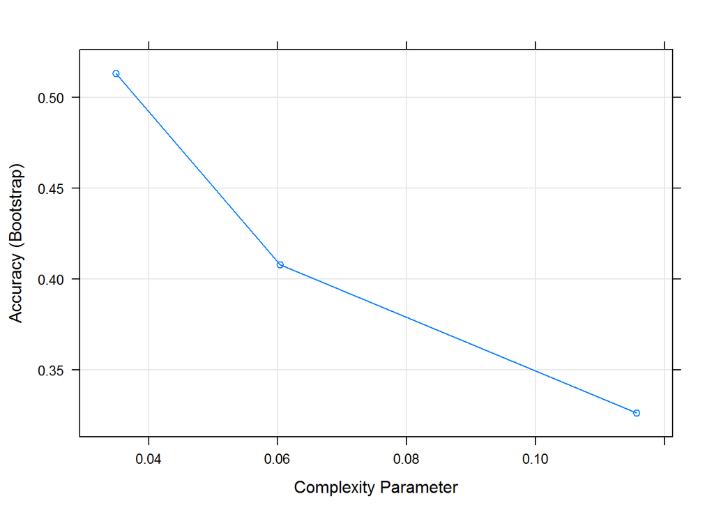

```r
plot(modFit)
```

We can see that the accuracy of this model is about 50% in the training as well as the cross-validation set. Hence we change the cross-validation approach.

#### rpart Approach 2: Using K-fold Cross-validation

We again try fitting a model using rpart, but using K-fold cross-validation with 10 folds.

```r
numFolds <- trainControl(method = "cv", number = 10)
modFit <- train(classe ~ ., method="rpart", trControl = numFolds, data=modTrain)
modFit
```

```
## CART
##
## 15743 samples
##    52 predictor
##     5 classes: 'A', 'B', 'C', 'D', 'E'
##
## No pre-processing
## Resampling: Cross-Validated (10 fold)
## Summary of sample sizes: 14168, 14169, 14168, 14170, 14169, 14169, ...
## Resampling results across tuning parameters:
##
##   cp          Accuracy   Kappa
##   0.03495697  0.4995235  0.34607628
##   0.06036140  0.4398044  0.24903027
##   0.11560642  0.3152522  0.04745259
##
## Accuracy was used to select the optimal model using the largest value.
## The final value used for the model was cp = 0.03495697.
```

```r
confusionMatrix(modFit)
```

```
## Cross-Validated (10 fold) Confusion Matrix
##
## (entries are percentual average cell counts across resamples)
##
##           Reference
## Prediction    A    B    C    D    E
##          A 25.9  8.0  8.1  7.4  2.7
##          B  0.4  6.5  0.5  2.9  2.5
##          C  2.0  4.3  8.5  5.4  4.3
##          D  0.1  0.5  0.3  0.7  0.6
##          E  0.1  0.0  0.0  0.0  8.3
##
##  Accuracy (average) : 0.4995
```

Model performance on the validation dataset:

```r
pred <- predict(modFit, newdata=validation)
confusionMatrix(pred,validation$classe)
```

```
## Confusion Matrix and Statistics
##
##           Reference
## Prediction   A   B   C   D   E
##          A 994 308 315 278 102
##          B  19 256  23 108  99
##          C  91 184 336 250 194
##          D   0   0   0   0   0
##          E   4   0   0   0 318
##
## Overall Statistics
##
##                Accuracy : 0.4908
##                  95% CI : (0.475, 0.5067)
##     No Information Rate : 0.2856
##     P-Value [Acc > NIR] : < 2.2e-16
##
##                   Kappa : 0.3347
##  Mcnemar's Test P-Value : NA
##
## Statistics by Class:
##
##                      Class: A Class: B Class: C Class: D Class: E
## Sensitivity            0.8971   0.3422  0.49852    0.000  0.44600
## Specificity            0.6380   0.9205  0.77566    1.000  0.99874
## Pos Pred Value         0.4977   0.5069  0.31848      NaN  0.98758
## Neg Pred Value         0.9394   0.8542  0.88031    0.836  0.88895
## Prevalence             0.2856   0.1928  0.17376    0.164  0.18381
## Detection Rate         0.2563   0.0660  0.08662    0.000  0.08198
## Detection Prevalence   0.5148   0.1302  0.27198    0.000  0.08301
## Balanced Accuracy      0.7676   0.6314  0.63709    0.500  0.72237
```

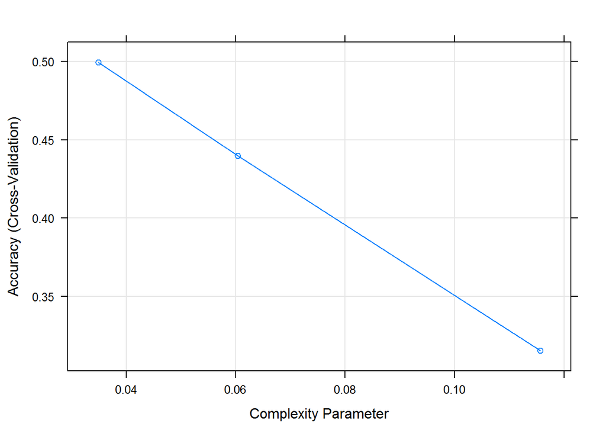

```r
plot(modFit)
```

We find that even after using K-fold for cross-validation, there is not much improvement in the model accuracy.

Hence we now try the Random Forest classification model.

### Random Forest

First we check the significant features using rfcv() function, using the default values of cv.fold=5, step=0.5 and scale=“log”:

```r
numCols <- length(names(modTrain))
modFit <- rfcv(trainx = modTrain[,-numCols], trainy = modTrain[,numCols])
```

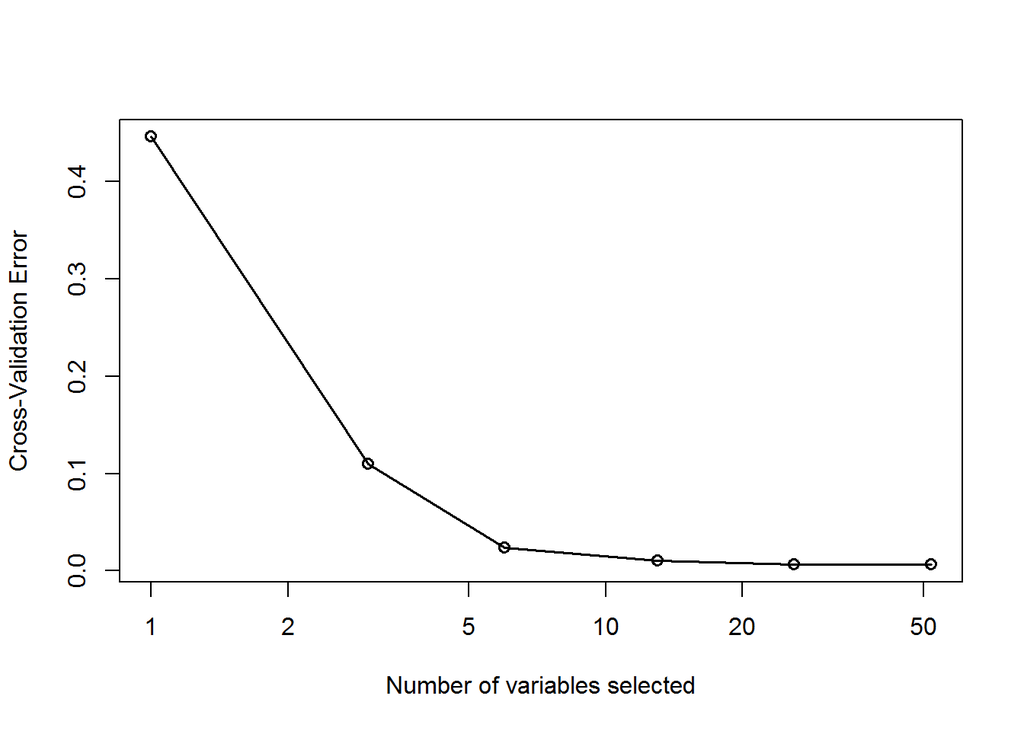

```r
plot(modFit$n.var, modFit$error.cv, log = "x", type = "o", lwd = 1.5,         xlab = "Number of variables selected", ylab = "Cross-Validation Error")
```

Thus, We can get a low cross-validation error by using only the 13 most important variables. To identify those variables, we run a generic Random Forest model and check the what the 13 most important variables are:

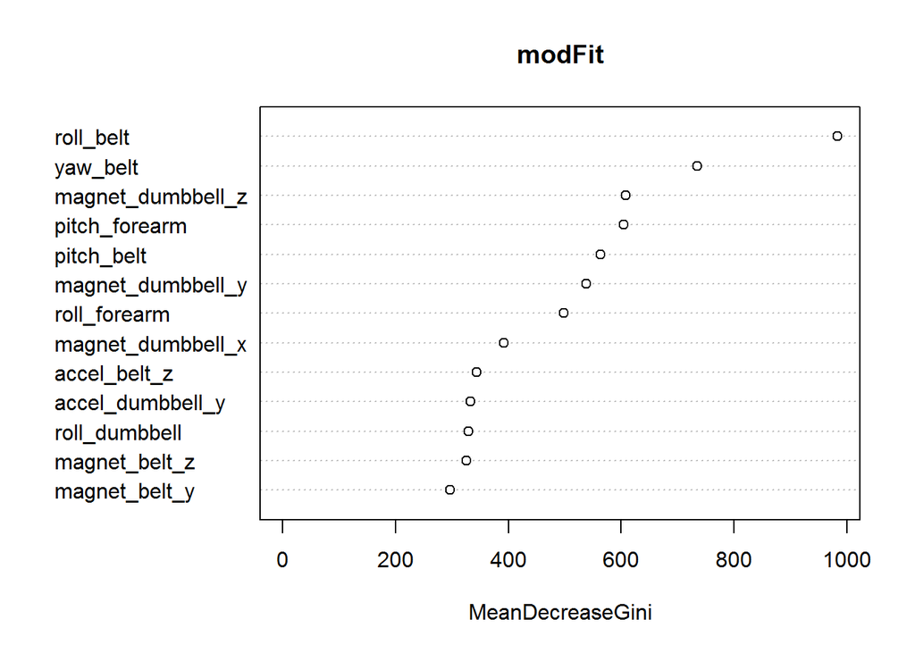

```r
n <- 13
modFit <- randomForest(classe ~ ., data=modTrain)
varImpPlot(modFit, n.var = n)
```

Next, we train another model using only the most important variables:

```r
vars <- varImp(modFit)
impCols <- rownames(vars)[order(vars, decreasing = TRUE)][1:n]
modFit <- randomForest(x = modTrain[,impCols], y = modTrain$classe)
```

Then we check the predictions made by this model on the validation set and compare them with the actual predictions:

```r
pred <- predict(modFit, newdata=validation)
confusionMatrix(pred,validation$classe)
```

```
## Confusion Matrix and Statistics
##
##           Reference
## Prediction    A    B    C    D    E
##          A 1102    4    0    0    0
##          B    4  731    1    1    1
##          C    1   10  665    4    0
##          D    1    3    8  630    5
##          E    0    0    0    1  707
##
## Overall Statistics
##
##                Accuracy : 0.9887
##                  95% CI : (0.9848, 0.9917)
##     No Information Rate : 0.2856
##     P-Value [Acc > NIR] : < 2.2e-16
##
##                   Kappa : 0.9857
##  Mcnemar's Test P-Value : NA
##
## Statistics by Class:
##
##                      Class: A Class: B Class: C Class: D Class: E
## Sensitivity            0.9946   0.9773   0.9866   0.9906   0.9916
## Specificity            0.9986   0.9978   0.9953   0.9948   0.9997
## Pos Pred Value         0.9964   0.9905   0.9779   0.9737   0.9986
## Neg Pred Value         0.9978   0.9946   0.9972   0.9981   0.9981
## Prevalence             0.2856   0.1928   0.1738   0.1640   0.1838
## Detection Rate         0.2841   0.1885   0.1714   0.1624   0.1823
## Detection Prevalence   0.2851   0.1903   0.1753   0.1668   0.1825
## Balanced Accuracy      0.9966   0.9875   0.9910   0.9927   0.9956
```

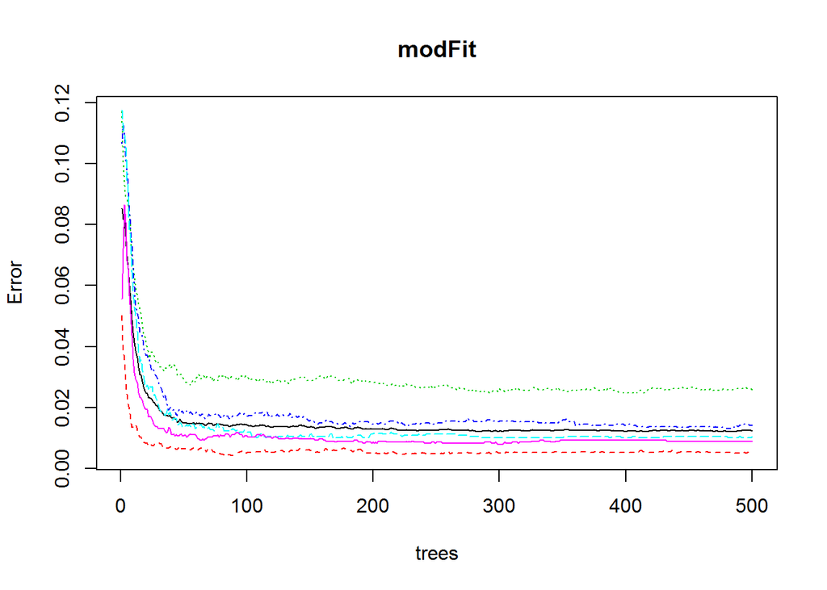

```r
plot(modFit)
```

We can see that the accuracy of the model in the validation set is about 99% and the 95% CI lies between 0.98 and 0.99.

Finally, we use the model to make predictions in the testing dataset and write the results out to a csv file to submit for evaluation:

```r
modTest <- subset(testing, select = setdiff(names(testing), names(a[a>0])))
modTest <- subset(modTest, select =  setdiff(names(modTest),c("X","user_name", "raw_timestamp_part_1", "raw_timestamp_part_2","cvtd_timestamp", "num_window", "new_window")))
modTest <- mutate(modTest, classe = "A")
testPred <- predict(modFit, newdata=modTest)
testing <- mutate(testing, classe = testPred)
write.csv(testing, file = "newtesting.csv")
```

## Conclusion

We conclude that qualitative prediction of weightlifting exercises can be successfully accomplished using a model that implements Random Forest with cross-validation.

## Reference

Velloso, E.; Bulling, A.; Gellersen, H.; Ugulino, W.; Fuks, H. Qualitative Activity Recognition of Weight Lifting Exercises. Proceedings of 4th International Conference in Cooperation with SIGCHI (Augmented Human ’13) . Stuttgart, Germany: ACM SIGCHI, 2013.